# discussion4mai

Antoine

5 04,2018

## control

On mesure le % de remplissage (par inf.) du stock de crop patches dans le paysage.

Il s’agit d’un control : différentes proportions d’éléments semi-naturels mais 0 prédateurs au départ

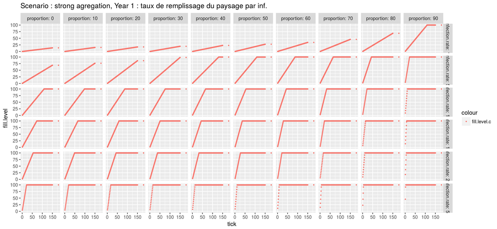

Remarque : le point que l’on voit à 180, c’est parce qu’il y a la période de retour aux semi-naturals pour l’hivernage, qui dure 30 ticks (150 -> 180) mais qui est calculée en une fois (je pourrai enlever, c’est pour illustration du fonctionnement du modèle)

Le taux de remplissage par inf. du control augmente et accélère avec proportion / inf.rate comme attendu

## control + data en présence de prédateurs

Comparaison des % de remplissage : control VS avec prédateurs

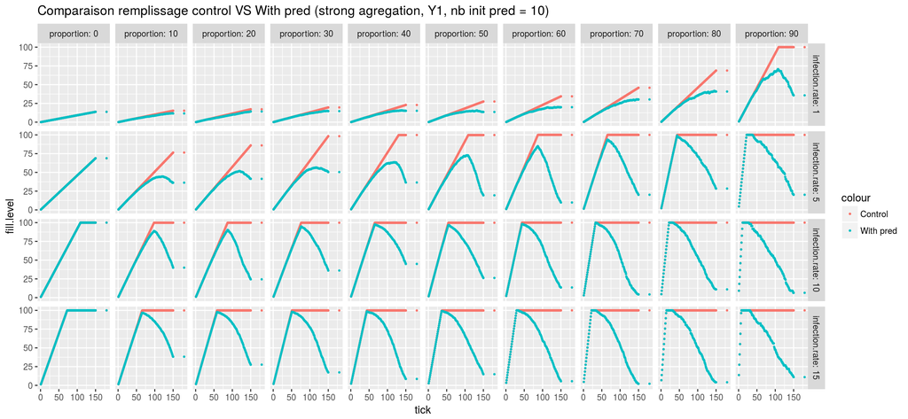

Le taux de remplissage total par inf. commence par suivre la courbe du control -> pas de contrôle biologique auu début de la simul., le temps que les prédateurs sortent (environ 7 days) et trouvent des patchs infectés

Ce taux décroît en fin de simul. d’autant + vite que la proportion est forte -> - de patchs à contrôler alors que la pop. de prédateurs augmente rapidement (pas de densité dépendance dans le modèle)

Il décroît aussi en fin de simul. d’autant + vite qu’inf.rate est fort… -> à priori curieux, ou alors la pop. de préds augmente très rapidement car inf.rate fort = bcp. de food et donc leur grand nb. permet de se projeter + rapidement en fin de simul. sur l’ensemble des crop patches infectés

## control + data -> découpage patchs occupés / non occupés

On découpe le % de remplissage entre :

- % de patchs crops infectés mais non-occupés par des prédateurs (adultes ou juv.)
- % de patchs crop infectés et occupés

Rappel :

- les patchs soignés redeviennent sains une fois guéris
- ils ne peuvent plus être infectés

-> d’où la diminution en fin de saison des patchs infectés occupés

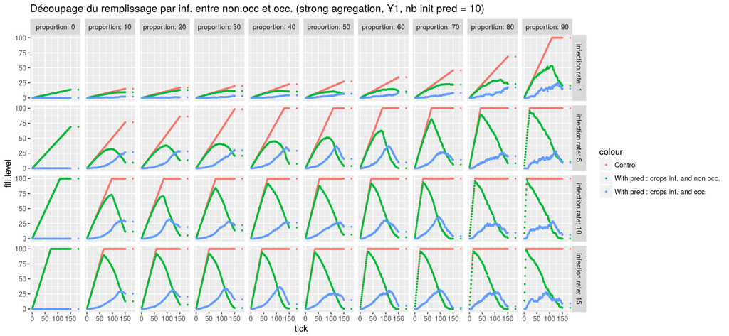

Lorsque proportion augmente, l’enveloppe des crops inf. et occ. augmente -> + de crops patches infectés sont visités rapidement et soignés et cela s’étale dans le temps = la guérison survient + tôt dans la saison

## Dynamique des prédateurs (adultes)

On regarde comment varie le nb. d’adultes sur 2 années différentes :

- Year 1
- Year 5 -> stabilisation de dyn. de la pop. entre années (observé visuellement)

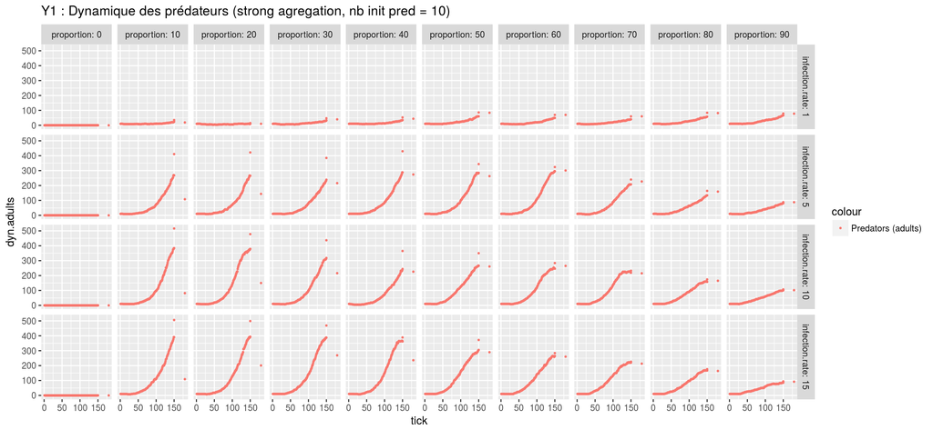

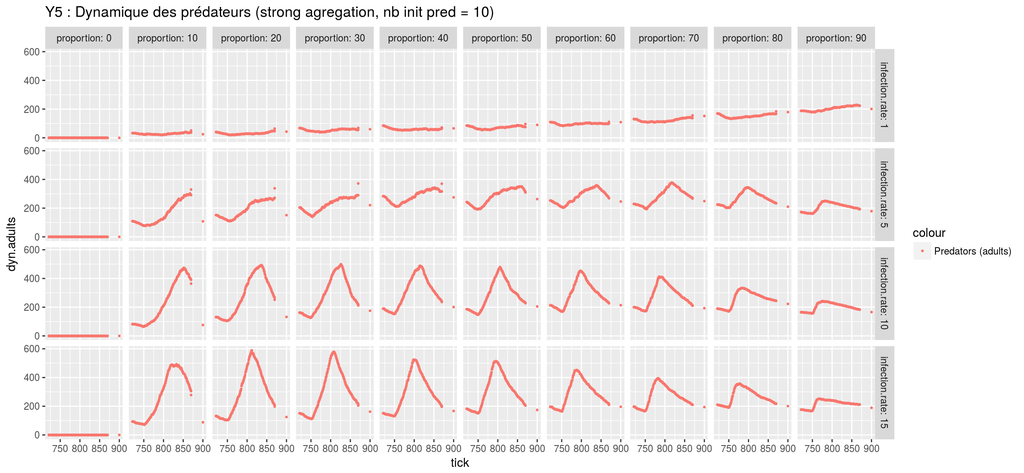

Remarques : les 2 points en fin de simul. correspondent à tick 150 (conversion en une fois des juv. en adults -> augmentation du nb. total d’adultes) et tick 180 (phénomène d’hivernage où l’on kill les pops. excessives dans les éléments semi-naturels)

Au cours de la saison, lorsque proporion augmente, le pic d’adultes survient + tôt et ensuite la mortalité combinée au manque de food (on autorise un seul cycle d’infection pour les patchs) fait diminuer leur nombre

## Durée d’infection des patchs avant arrivée d’un prédateur

t.fro.crop.loss (abscisse) = durée d’infection des patchs crops avant arrivée d’un prédateur

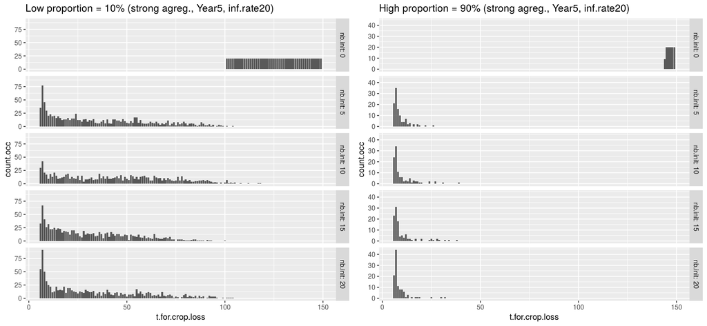

Comparaison des 2 plots = 2 scénarios de proportion d’éléments semi-naturels (Low = 10% VS High = 90%)

A proportion = 10%

- distribution assez étalée = durées plus longues entre infection et arrivée des prédateurs -> ceux-ci ont + de difficultés à trouver les patchs infectés
- pas de différence selon le nb. initial de prédateurs dans la simul.

A proportion = 90%

- distribution + resserrée sur la gauche = durées + faibles -> les prédateurs trouvent + rapidement les patchs crops infectéss
- pas non plus de différence selon le nb. initial de prédateurs dans la simul.

## Proportion / inf.rate -> effet sur distribution de t.for.crop.loss ?

Contrairement à la slide précédente :

- on fixe nb init. -> 10 adults
- plus de niveaux pour proportion
- on facet aussi inf.rate

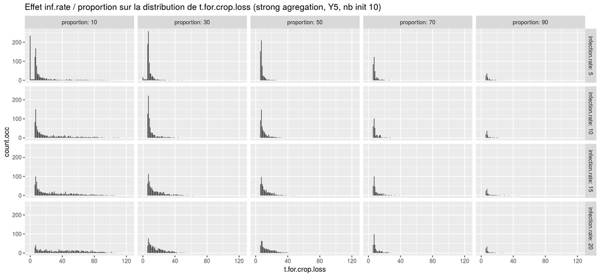

Remarque : on observe des pics à 0 et entre 0-5 pour inf.rate = 5 -> artefacts = inf.rate est trop faible pour infecter l’ensemble des crop patches et ils ont par défaut une valeur de t.for.crop.loss de 0, les valeurs entre 0-5 c’est parce que la simul. s’achève alors que les patchs sont dans leur période latente (5 en moyenne) -> il ne faut pas considérer ces valeurs entre 0-5 donc (je pourrai les enlever, je les ai laissé ici juste pour l’explication)

- On retrouve l’effet de la proportion décrit précédemment (distribution se ressere vers la gauche lorsque proportion augmente)
- A proportion = 10 la distribution est + étalée pour inf.rate = 20 / inf.rate = 5 -> + de patchs sont infectés à chaque tick alors que le nb de préds est limité